# Australian and Canadian Greenhouse Gas Emissions

2018-12-30T00:00:00

The conversation around greenhouse gas emissions in Australia differs from that in Canada. In Australia there is much attention on coal generation and renewable energy, where as in Canada the focus is on oil and gas, and in particular the oil sands and export pipelines. To get a sense of where emissions come from in each country this post breaks down and compares emission sources.

Here’s Australia’s and Canada’s emissions since 1990. The importance of energy emissions, and the growth in them since 1990, is clear. *Energy* is primarily the burning of fossil fuels for electricity, heat, and transportation. *Agriculture* includes emissions like methane, but not energy used in farm tractors, to heat greenhouses, etc. *Industrial proceses* are *Waste* emissions come directly from sources like cement or landfills, but like agriculture do not include associated fossil fuel use. *LULUCF* is land use, land-use change, and forestry.

Data for Canada comes from the [2018 National Inventory Report](http://data.ec.gc.ca/data/substances/monitor/national-and-provincial-territorial-greenhouse-gas-emission-tables/), and for Australia from the [National Greenhouse Gas Inventory via AGEIS](http://ageis.climatechange.gov.au/NGGI.aspx).

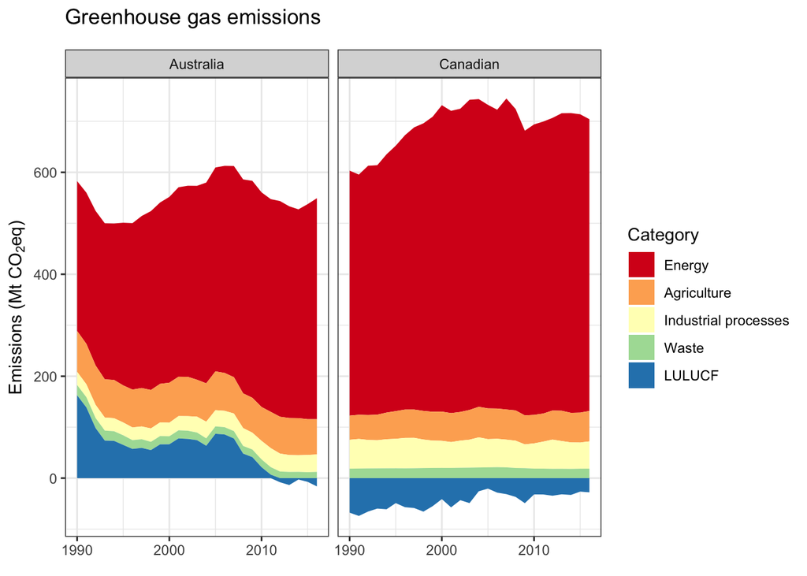

Emissions within the *Energy* category come from a variety of sources. I’ve plotted these emissions below, ordered largest to smallest by Australia’s 2016 emissions. Electricity and other fossil fuel related emissions are red-orange, and transportation emissions are in blue.

In Australia, electricity generation is the largest source of emissions owing to the widespread use of coal. The importance of coal industry is further evidence in fugitive emissions from coal mining being Australia’s 4th largest emissions source. Canada, with its relatively clean electricity emissions from legacy hydro power, has road transport as the largest source. While fugitive coal emissions are negligible in Canada, the importance of oil and gas can be seen through the large fossil fuel extraction and fugitive oil and gas emissions.

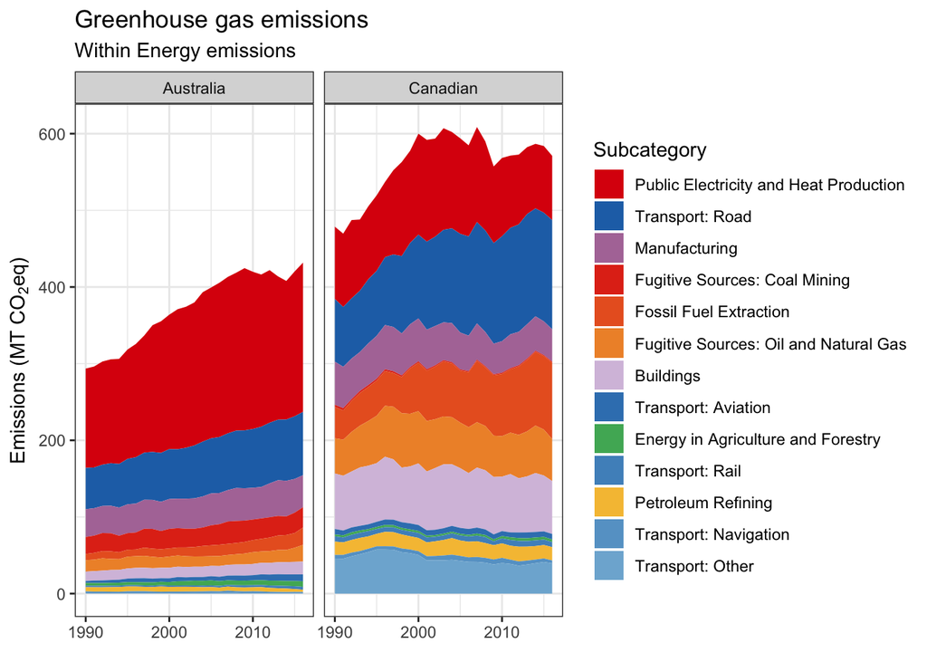

#### Provincial & State emissions

Emission sources differ substantially across Australia and Canada. Below, I plot all emissions excluding LULUCF by province/state, emission category, and year. I’ve separated *Energy* into electricity, transport, fossil fuel extraction activities, buildings, and manufacturing sources. For Canada, Alberta jumps out for both its high emissions and large share from the oil and gas industry. The importance of hydro power to BC and Quebec is clear in the lack of emissions from electricity generation. Emissions across Australian states are relatively uniform compared to Canada, though with South Australia and Western Australia having a smaller share from electricity generation.

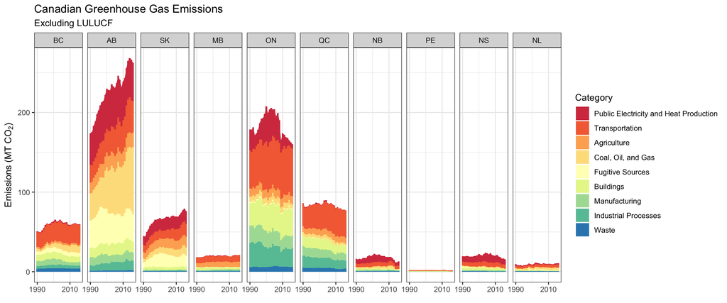

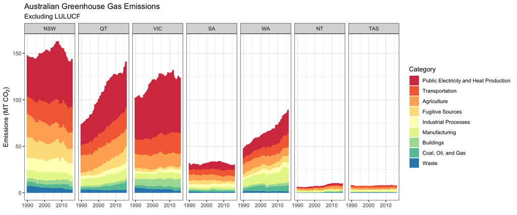